**Research question (v2):** "How much of the v1 headline — a 39-fold split between garlic-as-food-list and garlic-as-treatment — is a fact about the community, and how much is an artefact of one model labelling both variables in the same breath? And what is this corpus saying that v1's closed vocabulary had no slot for?"

# Garlic beliefs and use, v2: what survives an independence check

**Abstract.** This is a re-analysis of the same probe store, run id and extraction model as v1 (`deepseek/deepseek-v4-flash`, run `c05891b6…`); nothing was re-extracted. Every v1 count reproduces exactly. Three things change. **(1)** v1's headline contrast is inflated by same-claim labelling: `speech_act` and `polarity` are emitted in one JSON object, and the claim-level split (73.3% vs 6.2% anti-use) already equals the reporter-level headline. Sourcing polarity only from claims *other* than the camp-defining one, the split holds but falls from OR 38.8 (h = 1.59) to **OR 15.3 (h = 1.18)**. The two-system finding is real and should be reported at roughly the latter size. **(2)** v1's second finding — that a first-pass `treatment_outcome` field selects the use camp — survives the obvious confound. Stratifying by how many garlic tokens an account wrote, the odds ratio stays between 12.5 and 18.8 in every stratum; among accounts mentioning garlic exactly once it is 70.9% vs 13.5%. This, not the polarity split, is the strongest result in either notebook. **(3)** Two categories are missing from the schema. **113 of 640** self + actual-use accounts write about garlic alongside an anticoagulant or fibrinolytic (nattokinase, serrapeptase, aspirin, apixaban); 2 produce any `warning` claim and 1 a bleeding adverse event. And **61 accounts** describe parosmia or flavour loss, which has no mechanism label — 22 of them are scored `food_list`, feeding the anti-use camp with a mechanism that is not histamine.

Same caveats as v1: shares of extractable reports at the account level, not efficacy, incidence or dose-response.

## What v2 changes

| v1 said | v2 finds | Direction |
| --- | --- | --- |
| Polarity split OR 38.8, Cohen's h 1.59, **Strong** tier | OR 15.3, h 1.18 when polarity is taken from a different claim | Real, ~2.5× smaller; demote to **Moderate** |
| JSON-vs-FTS split, **Strong** tier | Flat OR 12.5–18.8 across garlic-volume strata | Confirmed; **promote to the lead finding** |
| Circulation is "a third camp", framed as a taxonomy surprise | It is the microclot/blood-thinner protocol, and it is a safety gap | Reframed, new |
| "Some list-shaped posts may be landing in `culinary`" | 1% of culinary quotes carry trigger language vs 34% of food_list | v1's self-critique points the wrong way |
| Parosmia | Not in the schema; 61 accounts, 22 mislabelled `food_list` | New |
| Wilson CIs on account shares | 42 accounts carry 19.6% of claims; camps differ in claims/account | Independence is weaker than the CIs imply |

Everything else in v1 — the preparation mix, the mechanism FDR scan, the gut/biofilm null, the Stage 5b agreement — reproduces and is not restated here.

> **Inherited caution (GATE 4).** A blind labelling pass on 80 windows agreed with the model on only 5 of 12 rows where either party assigned `food_list`, `avoidance` or `culinary`. Those labels remain provisional in v2, and §5 shows the failure is not the one v1 guessed.

## 0. Verification: v1 reproduces exactly

Before re-testing anything, confirm the v2 environment reads the same run and returns v1's numbers. These are recomputed from the store, not copied.

Reporter-level speech-act presence over 1,927 complete-extraction accounts. An account may hold more than one act.

| speech act | accounts | v1 reported | match |
| --- | --- | --- | --- |
| actual_use | 650 | 650 | ✓ |
| culinary | 408 | 408 | ✓ |
| food_list | 355 | 355 | ✓ |
| recommendation | 297 | 297 | ✓ |
| mechanism_belief | 179 | 179 | ✓ |
| other | 166 | 166 | ✓ |
| question | 164 | 164 | ✓ |
| avoidance | 109 | 109 | ✓ |
| planned_or_considered | 96 | 96 | ✓ |
| warning | 15 | 15 | ✓ |

**v1 headline reproduces:** food_list 144/181 (79.6%) vs actual_use 36/395 (9.1%) anti-use, OR = 38.8, Cohen’s h = 1.59. Exact match to v1.

## 1. How much of the headline is the model labelling itself?

`speech_act` and `polarity` are two fields of one JSON object emitted in one pass. v1 notes this under Confounding but still reports the contrast at full size. The test is cheap: if the split were a fact about accounts rather than about sentences, aggregating claims to accounts should *add* signal. It does not — the claim-level table below already carries the whole effect.

Claim-level cross-tab of the two fields the headline contrasts, in the same JSON object. The 73.3% / 6.2% food_list-vs-actual_use gap here is already the reporter-level headline.

| polarity | speech act | pro_use | anti_use | mixed | unclear | (none) | anti-use % of scored |
| --- | --- | --- | --- | --- | --- | --- | --- |
|  | actual_use | 719 | 50 | 24 | 10 | 609 | 6.20 |
|  | food_list | 66 | 211 | 9 | 2 | 203 | 73.30 |
|  | culinary | 6 | 1 | 1 | 0 | 486 | 12.50 |
|  | recommendation | 332 | 16 | 6 | 0 | 101 | 4.50 |
|  | mechanism_belief | 145 | 35 | 10 | 15 | 12 | 17.10 |
|  | question | 23 | 8 | 4 | 9 | 144 | 18.20 |
|  | other | 7 | 11 | 2 | 0 | 171 | 55.00 |
|  | avoidance | 0 | 91 | 2 | 0 | 45 | 97.80 |
|  | planned_or_considered | 55 | 1 | 5 | 0 | 55 | 1.60 |
|  | warning | 0 | 13 | 3 | 2 | 3 | 72.20 |

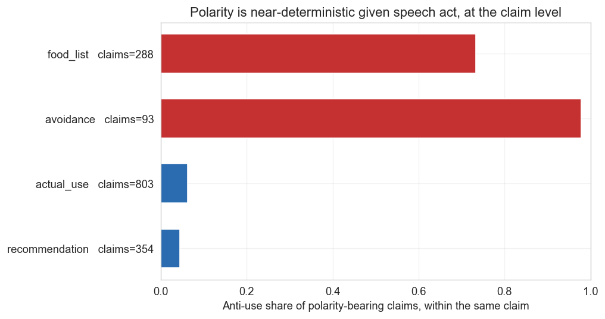

Exclusive camps. The second row is the same contrast with the circularity removed: an account's camp comes from one claim, its polarity from a different one. Sample is much smaller because most accounts write a single claim.

| polarity source | food_list anti-use | actual_use anti-use | OR | p | h |
| --- | --- | --- | --- | --- | --- |
| any claim (v1 primary) | 144/181 (79.6%) | 36/395 (9.1%) | 38.81 | 9.12e-65 | 1.59 |
| claims other than the camp-defining act | 18/29 (62.1%) | 11/114 (9.6%) | 15.32 | 1.38e-08 | 1.18 |

**Test.** Fisher’s exact on anti-use polarity from a different claim: food_list only 18/29 (62.1%) vs actual_use only 11/114 (9.6%). Odds ratio 15.32 (95% CI 5.78–40.59), p = 1.38e-08, Cohen’s h = 1.18.

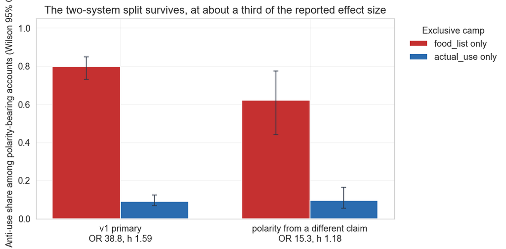

**Verdict.** The split is not an artefact — 62% vs 10% at p = 1.4e-08 on independent claims. But the headline effect size is inflated about 2.5× by within-claim coupling. Report OR ≈ 15, not 39. The cross-claim cut rests on 29 food-list accounts, so it is a direction check, not a precise estimate.

## 2. The methods finding, stress-tested

v1's second headline: accounts the first-pass extractor already tagged with garlic are overwhelmingly labelled `actual_use`, while accounts only full-text search retrieved are not. The obvious objection is salience — maybe the first pass simply caught the people who wrote *more* about garlic, and volume drives the use label. JSON-garlic accounts do write more. Stratify on that and see whether the effect survives.

Actual-use labelling among JSON-garlic (n = 500) vs FTS-only (n = 1,427) complete accounts, stratified by how many garlic/allicin/kyolic tokens the account actually wrote. If the v1 finding were a salience artefact, the odds ratio would collapse toward 1 in the low strata.

| garlic tokens written | JSON n | JSON actual_use | FTS-only n | FTS-only actual_use | OR | p |
| --- | --- | --- | --- | --- | --- | --- |
| 1 | 206 | 70.9% | 978 | 13.5% | 15.60 | 5.70e-60 |
| 2 | 94 | 78.7% | 233 | 16.7% | 18.41 | 3.10e-26 |
| 3–4 | 89 | 84.3% | 137 | 29.9% | 12.54 | 3.78e-16 |
| 5–9 | 66 | 92.4% | 61 | 39.3% | 18.81 | 8.55e-11 |
| 10+ | 45 | 97.8% | 18 | 77.8% | 12.57 | 0.0208 |

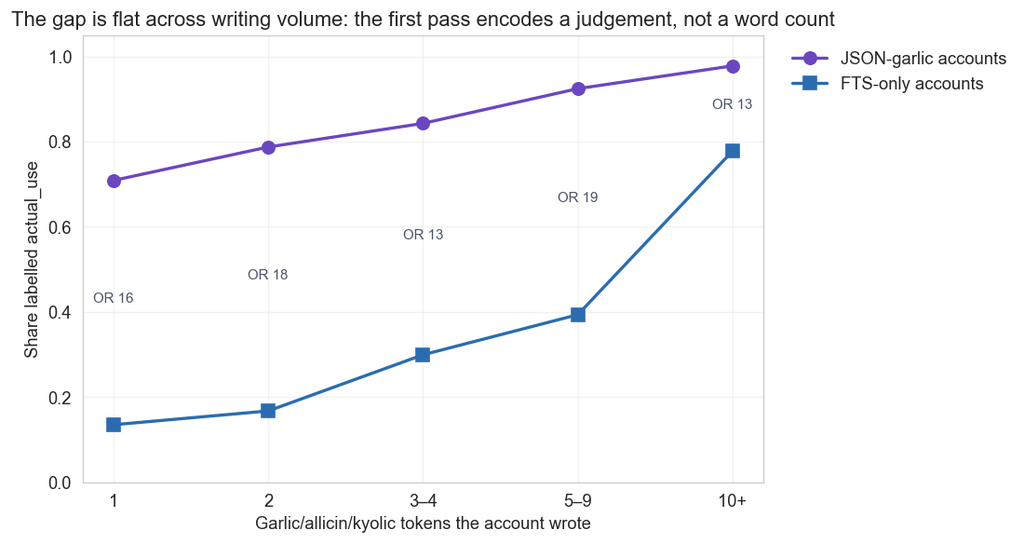

**Verdict.** The odds ratio stays between 12.5 and 18.8 in every stratum. Among accounts that mention garlic exactly once, 70.9% of JSON-garlic accounts are labelled actual_use against 13.5% of FTS-only accounts. Salience does not explain it. This is the most robust result in either notebook, and it is a fact about the pipeline, not about garlic.

## 3. The circulation camp is the microclot protocol — and nobody is warning about it

v1 found `cardiovascular_or_bleeding` to be the second-largest mechanism, noted it sits with the use camp "mostly as pro-use … not as an anticoagulant warning," and filed it as a surprise about the design's two-system frame. Read against the corpus, that absence of warnings is the finding. Garlic has documented antiplatelet activity; this community is stacking it *deliberately* with nattokinase, serrapeptase and prescription anticoagulants, as part of the long-COVID microclot protocol.

Co-mention is not co-ingestion: the flag says an anticoagulant or fibrinolytic name appears in the same account's garlic windows. It is an upper bound on stacking and a lower bound on the reporting gap.

| group | accounts |
| --- | --- |
| self + actual_use accounts | 640 |
| …co-writing an anticoagulant / fibrinolytic | 113 |
| …of those, any `warning` claim | 2 |
| …of those, a bleeding/anticoagulant adverse event | 1 |
| …of those, ANY adverse event reported | 17 |
| bleeding/anticoagulant AE, whole cohort | 3 |
| `warning` speech act, whole cohort | 15 |

**Test.** Fisher’s exact on an anticoagulant / fibrinolytic named in the same windows: self + actual_use accounts 113/640 (17.7%) vs all other complete accounts 52/1287 (4.0%). Odds ratio 5.09 (95% CI 3.61–7.18), p = 5.51e-22, Cohen’s h = 0.46.

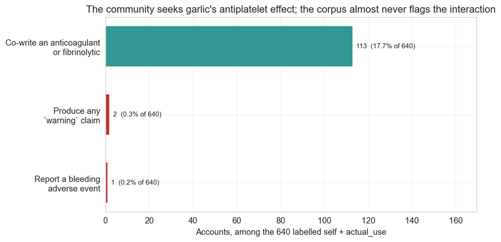

**Safety gap.** 113 of 640 self + actual-use accounts (17.7%, against 8.6% cohort-wide) name an anticoagulant or fibrinolytic in the same windows as their garlic use. 2 produce any `warning` claim and 1 a bleeding adverse event; cohort-wide the `bleeding_or_anticoagulant` category reaches 3 accounts. 33 use accounts write explicit microclot/fibrin language. This is the one place the corpus carries actionable clinical signal, and v1 does not state it.

## 4. A category the closed vocabulary cannot see: parosmia

Sampling the `culinary` bucket turns up *"garlic tastes like wet garbage"* and *"foods with a lot of garlic are exceptions to flavour loss."* That is parosmia and anosmia — a core long-COVID symptom, and one garlic is a natural probe for, because it is pungent enough to test with. The schema has no speech act and no mechanism for it, so those accounts scatter.

Where the 61 accounts describing smell/taste distortion land in a taxonomy with no slot for them. They can hold more than one act.

| speech act | smell/taste accounts | % of that act |
| --- | --- | --- |
| food_list | 22 | 6.2% |
| other | 21 | 12.7% |
| culinary | 13 | 3.2% |
| avoidance | 6 | 5.5% |
| actual_use | 3 | 0.5% |
| recommendation | 1 | 0.3% |
| mechanism_belief | 1 | 0.6% |
| question | 1 | 0.6% |

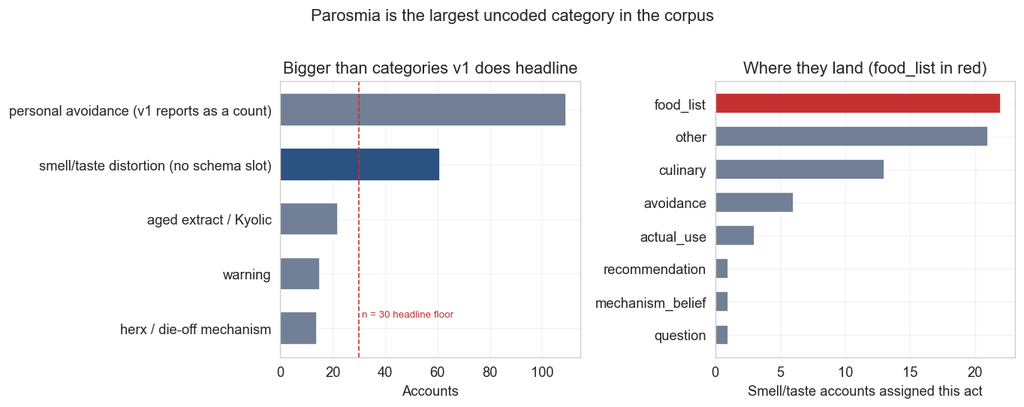

**Contamination of the anti-use camp.** 61 accounts (3.2%) describe smell or taste distortion — larger than herx, warning or Kyolic, all of which v1 codes. 22 of them are scored `food_list`. “Garlic tastes like garbage now” is being counted as the same speech act as “garlic triggers my mast cells,” and it feeds the anti-use side of the §1 contrast. Mechanisms assigned to these accounts are other (3), allium_intolerance (1), antimicrobial (1) — none of which is the right one.

## 5. v1's own self-critique points the wrong way

v1 §2 worries that `culinary` overshoots its keyword floor (408 vs 201) while `food_list` undershoots (355 vs 536), and concludes "some list-shaped posts may be landing in `culinary`." That is checkable against the stored evidence quotes.

Evidence-quote language for the two labels v1 suspected of bleeding into each other. If list-shaped posts were landing in `culinary`, the culinary row would carry trigger language.

| speech act | claims | listy | share with avoid/trigger/histamine language |
| --- | --- | --- | --- |
| culinary | 494 | 5 | 1.0% |
| food_list | 491 | 168 | 34.2% |

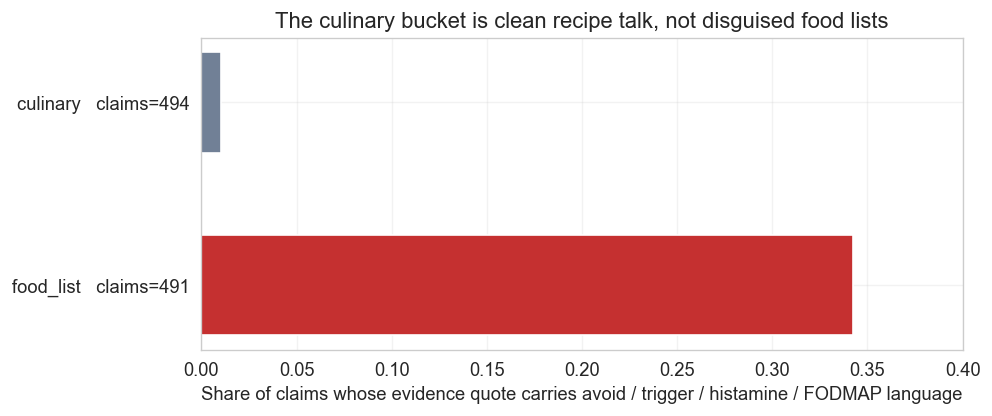

**The suspected leak is not there.** 1% of culinary quotes carry trigger language against 34% of food_list quotes. The culinary overshoot is a bad keyword floor — a regex for recipe talk is hard to write — not label leakage. GATE 4's 5/12 is still unresolved, but §4 suggests the real confusion runs parosmia → food_list, which nobody looked for.

## 6. Independence is weaker than the confidence intervals imply

Every Wilson interval in v1 treats one account as one independent draw. Two things complicate that: claim volume is very skewed, and the two camps are skewed differently.

The use camp writes more, so it has more chances to receive a polarity label. The §1 denominators are therefore not ascertained equally between camps.

| camp | accounts | mean claims | median claims | single-claim % | has any polarity % |
| --- | --- | --- | --- | --- | --- |
| food_list only | 312 | 1.70 | 1.00 | 71.8% | 58.0% |
| actual_use only | 607 | 2.63 | 1.00 | 53.7% | 65.1% |

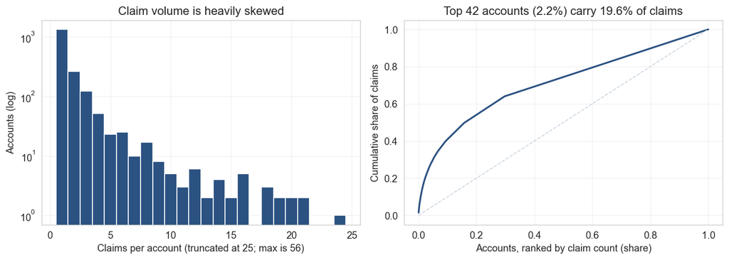

**Read the intervals as optimistic.** 42 accounts carry 19.6% of all claims. The food-list camp is 72% single-claim against 54% for the use camp, and differs in the rate at which it receives any polarity at all (58% vs 65%) — differential ascertainment, not just noise. Separately, 20 complete-extraction accounts produced no claim and sit silently in every denominator. v1's sensitivity cut drops the top four accounts; the issue is the shape of the whole distribution.

## 7. Revised tiers

Same rules as v1 (n ≥ 30 and p < 0.05 for Strong), applied to what survived §1–§6.

Everything here is about how to read the corpus and the pipeline. Nothing here is about whether garlic works, which this design cannot answer.

| tier | finding | changed from v1 |
| --- | --- | --- |
| Strong | Do not build a garlic-use cohort from a first-pass treatment field. The JSON-vs-FTS gap is flat across writing volume (OR 12.5–18.8 in every stratum), so it is a judgement encoded by the extractor, no… | promoted to lead |
| Moderate | Garlic-as-list and garlic-as-treatment are different speech acts with opposite polarity. Real, but OR ≈ 15 and h ≈ 1.2 once polarity is sourced from a different claim — not OR 38.8. | demoted from Strong |
| Moderate | Among self + actual-use accounts, 17.7% name an anticoagulant or fibrinolytic in the same windows, with almost no warning or bleeding-AE reporting. A reporting gap, not an incidence rate. | new |
| Preliminary | Parosmia / flavour loss is the largest uncoded category (61 accounts) and 22 of those are scored food_list. Needs a schema slot before the §1 contrast can be trusted at the margin. | new |
| Preliminary | The culinary bucket is clean; GATE 4's failure is probably parosmia → food_list, not food_list → culinary. Still unadjudicated. | corrects v1's self-critique |

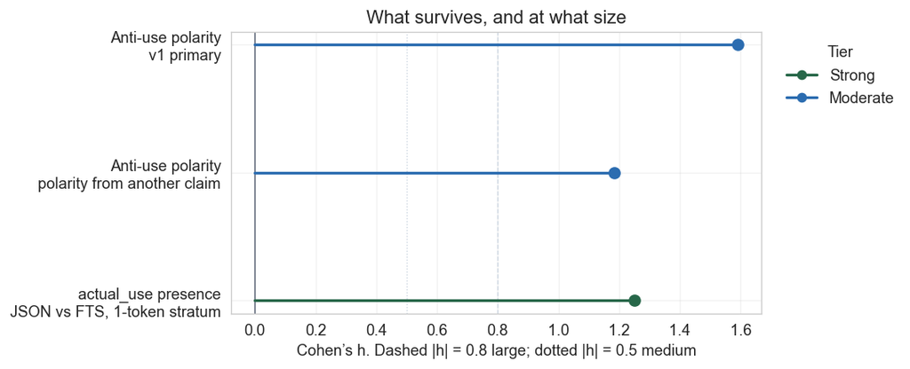

## 8. Conclusion

v1's story holds in shape and shrinks in size. Garlic really is two folk systems sharing a word: one camp lists it as a trigger, another takes it as a treatment, and their polarity runs in opposite directions. But the 39-fold odds ratio was measuring a single model deciding both facts about one sentence at once. Asked to derive the two labels from different sentences by the same account, the community difference is about OR 15 — still large, still the right qualitative reading, and roughly a third of the advertised effect.

The finding that should lead is the methods one, because it is the one that got harder to explain away rather than easier. A first-pass treatment extractor and a full-text gate retrieve different populations from the same corpus, and they do so at the same rate whether an account wrote one garlic sentence or fifty. Anyone assembling a cohort from an extracted-treatment field in this database is selecting on the pipeline's implicit theory of what counts as a treatment, and that selection is strong enough to invert which camp looks like the majority.

What remains open is unchanged from v1 and now more pointed: GATE 4 never cleared, and §4 and §5 together suggest the unresolved boundary is not the one v1 suspected. Adding a parosmia speech act and re-running the same windows would cost little and would test the §1 contrast at its weakest margin.

## 9. Limitations specific to v2

**Same store, same model, same run.** Nothing was re-extracted. Every v1 limitation carries: self-selected posters, no control arm, positive labels over-called by roughly 10–20%, `not_stated` as the majority for adverse events, and a `deepseek/deepseek-v4-flash` extractor that agrees with itself on `speech_act` only 79.4% of the time at temperature 0. That instability is a floor under every contrast here, including the ones v2 adds.

**The cross-claim test trades circularity for power.** Restricting polarity to non-camp claims leaves 29 food-list and 114 actual-use accounts. The direction is unambiguous, the magnitude is not. OR 15.3 should be read as "large, and smaller than 38.8," not as a point estimate. It is also not fully independent: both claims come from one account, one model and often one window.

**Co-mention is not co-ingestion.** §3's anticoagulant flag fires when a drug or enzyme name appears anywhere in an account's garlic windows. Some of those accounts are discussing, not combining. The flag is an upper bound on stacking. The reporting gap it measures — 2 warnings across 113 accounts — is robust to that, because the denominator being loose only makes the numerator more surprising.

**The parosmia flag is a regex, not a label.** §4 counts accounts whose windows match smell/taste-distortion language. It has no adjudication behind it and will both over- and under-fire. It is offered as evidence that a category is missing, not as a measurement of how many people have parosmia.

**No multiplicity control on the new contrasts.** §3, §4 and §5 are three planned follow-ups to a specific reading of v1, not a scan. They are reported unadjusted and tiered accordingly. The only FDR-controlled family in this study remains v1's eight-mechanism scan.

**Regex flags see the whole window, labels see a claim.** The text flags in §3, §4 and §6 operate on an account's concatenated garlic windows, while speech acts are per-claim. Joining the two levels attributes window context to claim labels, which is exactly the confound §1 criticises v1 for — applied here to generate hypotheses rather than to size an effect.

Provenance. Database SHA-256 is of the probe store; do not commit that file.

| item | value |
| --- | --- |
| database | garlic_pharmacology.db |
| database SHA-256 | 7caae438b3512ea0cb4a59f2956d3417b0b7abfde34a234dfab3e7b3d32eb4f0 |
| run ID (pinned) | c05891b6ecad47900230eb606afbb230a9867fc9f41d1d2b88ec0292a05b03df |
| run created | 2026-08-12T23:40:00.979171+00:00 |
| model | deepseek/deepseek-v4-flash |
| provider / base URL | openai / https://openrouter.ai/api |
| sampling | temperature 0.0, max_tokens 32,768, reasoning_effort medium |
| HTTP timeout (not in run_id) | connect=10, read=90, write=90, pool=60 |
| prompt version | 2026-08-12-v3 (short-paraphrase contract) |
| quote grounding floor | 0.5 bag-of-words, no verbatim companion |
| source snapshot | reddit_2026-06-13.db |
| content date range | unavailable — timestamps are not loaded and chronology is never inferred |
| cohort | FTS `garlic OR allicin OR kyolic`, non-bot authors |
| execution date (UTC) | 2026-08-13 |
| loader | studies/garlic/garlic.py |
| inference | no p-values; Wilson intervals on reporter shares, reporter-clustered bootstrap on row-level rates |
| headline bin floor | reporter n ≥ 30 |
| notebook | studies/garlic/analysis_grok/garlic_beliefs_and_use_v2.ipynb |
| supersedes | garlic_beliefs_and_use.ipynb (v1) — same run_id, no re-extraction |
| extraction model | deepseek/deepseek-v4-flash |
| v2 additions | cross-claim polarity contrast; salience-stratified JSON/FTS; anticoagulant co-mention; parosmia flag; quote-language boundary check |
| text handling | window text and evidence quotes are reduced to booleans inside text_flags()/quote_flags() and never returned |

Stage 5b temperature-0 repeat, unchanged from v1 (units complete in both stores: 38; claim pairs: 68). This is the instability floor under every number above.

| metric | n | of | rate |
| --- | --- | --- | --- |
| top-level field set identical | 52 | 68 | 76.5% |
| shared top-level values equal | 541 | 609 | 88.8% |
| all shared fields equal identical | 21 | 68 | 30.9% |
| speech_act identical | 54 | 68 | 79.4% |
| subject identical | 61 | 68 | 89.7% |
| exposure_status identical | 61 | 68 | 89.7% |
| polarity identical | 53 | 68 | 77.9% |
| preparation identical | 63 | 68 | 92.6% |

These findings reflect reporting patterns in online communities, not population-level treatment effects. This is not medical advice.